**Hai Vu**

**Northeastern University**

Ames Housing Price Analysis  
Hai Vu

```r
# Libraries
rm(list=ls())
library(RColorBrewer)
library(xlsx)
library(gmodels)
library(knitr)
library(ggplot2)
library(ggpubr)
library(hrbrthemes)
library(dplyr)
library(corrplot)
library(tidyverse)
library(tibble)
library(psych)
library(Rmisc)
library(vcd)
library(MASS)
library(leaps)
library(plm)
library(mctest)
library(car)
```

# I. INTRODUCTION SECTION

The data set contains from the Ames Assessor’s Office used in computing assessed values for individual residential properties sold in Ames, Iowa from 2006 to 2010. Based on the given variables, this project hopes to generate predictions for housing sales price using the lease squares regression models. The independent variable in this case will be “SalePrice”, while other variables are considered potential predictors.

# II. ANALYSIS SECTION

## P1. Load the dataset

```r
# Data set loaded
df1 <- read.csv("AmesHousing.csv", check.names=F)
df_test <- distinct(df1) # remove duplicates (if any)
tibble::glimpse(df_test)
```

```
## Rows: 2,930
## Columns: 82
## $ Order             <int> 1, 2, 3, 4, 5, 6, 7, 8, 9, 10, 11, 12, 13, 14, 15, 1…
## $ PID               <int> 526301100, 526350040, 526351010, 526353030, 52710501…
## $ `MS SubClass`     <int> 20, 20, 20, 20, 60, 60, 120, 120, 120, 60, 60, 20, 6…
## $ `MS Zoning`       <chr> "RL", "RH", "RL", "RL", "RL", "RL", "RL", "RL", "RL"…
## $ `Lot Frontage`    <int> 141, 80, 81, 93, 74, 78, 41, 43, 39, 60, 75, NA, 63,…
## $ `Lot Area`        <int> 31770, 11622, 14267, 11160, 13830, 9978, 4920, 5005,…
## $ Street            <chr> "Pave", "Pave", "Pave", "Pave", "Pave", "Pave", "Pav…
## $ Alley             <chr> NA, NA, NA, NA, NA, NA, NA, NA, NA, NA, NA, NA, NA, …
## $ `Lot Shape`       <chr> "IR1", "Reg", "IR1", "Reg", "IR1", "IR1", "Reg", "IR…
## $ `Land Contour`    <chr> "Lvl", "Lvl", "Lvl", "Lvl", "Lvl", "Lvl", "Lvl", "HL…
## $ Utilities         <chr> "AllPub", "AllPub", "AllPub", "AllPub", "AllPub", "A…
## $ `Lot Config`      <chr> "Corner", "Inside", "Corner", "Corner", "Inside", "I…
## $ `Land Slope`      <chr> "Gtl", "Gtl", "Gtl", "Gtl", "Gtl", "Gtl", "Gtl", "Gt…
```

[output cut: 69 more lines]

P1 Observations:

- The given data set contains no duplicates as there are no changes when using function distinct()
- There are a total of 2930 observations and 82 variables

## P2. Perform EDA and show descriptive statistics

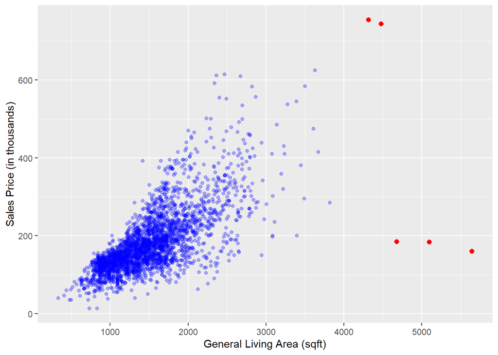

```r
# Irregularities found in houses with living area > 4000 (as instructed in the text file)
highlight_df <- df_test %>%
  filter(`Gr Liv Area`> 4000)

df_test %>%
  ggplot(aes(x=`Gr Liv Area`,y=SalePrice/1000)) +
  geom_point(alpha=0.3,
             color="blue") +
  geom_point(data=highlight_df,
             aes(x=`Gr Liv Area`,y=SalePrice/1000),
             color="red",
             size=2) +
  xlab("General Living Area (sqft)") +
  ylab("Sales Price (in thousands)")
```

```r
# Remove rows with living area > 4000
df_main <- df_test %>%
  filter(`Gr Liv Area`<= 4000)

df_char <- select_if(df_main,is.character)
df_num <- select_if(df_main,is.numeric)

# Show descriptive statistics of the numerical values
num_stats <- describe(df_num)[,c('n','mean','median','sd','min','max')]
num_stats
```

```
##                    n         mean      median           sd       min        max
## Order           2925      1464.79      1463.0       846.44         1       2930
## PID             2925 714393108.54 535453210.0 188727443.91 526301100 1007100110
## MS SubClass     2925        57.40        50.0        42.67        20        190
## Lot Frontage    2435        69.02        68.0        22.71        21        313
## Lot Area        2925     10103.58      9428.0      7782.00      1300     215245
## Overall Qual    2925         6.09         6.0         1.40         1         10
## Overall Cond    2925         5.56         5.0         1.11         1          9
## Year Built      2925      1971.30      1973.0        30.24      1872       2010
## Year Remod/Add  2925      1984.23      1993.0        20.86      1950       2010
## Mas Vnr Area    2902       100.71         0.0       176.03         0       1600
## BsmtFin SF 1    2924       438.10       369.5       438.03         0       2288
## BsmtFin SF 2    2924        49.81         0.0       169.30         0       1526
## Bsmt Unf SF     2924       558.95       464.5       439.62         0       2336
## Total Bsmt SF   2924      1046.85       989.5       421.11         0       3206
## 1st Flr SF      2925      1155.46      1082.0       376.59       334       3820
## 2nd Flr SF      2925       333.83         0.0       425.84         0       1862
## Low Qual Fin SF 2925         4.68         0.0        46.35         0       1064
## Gr Liv Area     2925      1493.98      1441.0       486.27       334       3820
## Bsmt Full Bath  2923         0.43         0.0         0.52         0          3
## Bsmt Half Bath  2923         0.06         0.0         0.24         0          2
## Full Bath       2925         1.56         2.0         0.55         0          4
## Half Bath       2925         0.38         0.0         0.50         0          2
## Bedroom AbvGr   2925         2.85         3.0         0.83         0          8
## Kitchen AbvGr   2925         1.04         1.0         0.21         0          3
## TotRms AbvGrd   2925         6.43         6.0         1.56         2         14
## Fireplaces      2925         0.60         1.0         0.65         0          4
## Garage Yr Blt   2766      1978.09      1979.0        25.53      1895       2207
## Garage Cars     2924         1.77         2.0         0.76         0          5
## Garage Area     2924       471.88       480.0       213.82         0       1488
## Wood Deck SF    2925        93.39         0.0       126.03         0       1424
## Open Porch SF   2925        47.17        27.0        66.57         0        742
## Enclosed Porch  2925        23.05         0.0        64.19         0       1012
## 3Ssn Porch      2925         2.60         0.0        25.16         0        508
## Screen Porch    2925        16.03         0.0        56.13         0        576
## Pool Area       2925         1.89         0.0        32.96         0        800
## Misc Val        2925        44.91         0.0       472.24         0      15500
## Mo Sold         2925         6.22         6.0         2.71         1         12
## Yr Sold         2925      2007.79      2008.0         1.32      2006       2010
## SalePrice       2925    180411.57    160000.0     78554.86     12789     625000
```

```r
# Show descriptive statistics of the categorical values
char_uniq <- as.matrix(lengths(lapply(df_char,unique)))
char_n <- describe(df_char)[,c('n')]
char_stats <- cbind(char_uniq,char_n)
colnames(char_stats) <- c("Unique","Count")
char_stats
```

```
##                Unique Count
## MS Zoning           7  2925
## Street              2  2925
## Alley               3   198
## Lot Shape           4  2925
## Land Contour        4  2925
## Utilities           3  2925
## Lot Config          5  2925
## Land Slope          3  2925
## Neighborhood       28  2925
## Condition 1         9  2925
## Condition 2         8  2925
## Bldg Type           5  2925
## House Style         8  2925
## Roof Style          6  2925
## Roof Matl           7  2925
## Exterior 1st       16  2925
## Exterior 2nd       17  2925
## Mas Vnr Type        6  2925
## Exter Qual          4  2925
## Exter Cond          5  2925
## Foundation          6  2925
## Bsmt Qual           7  2846
## Bsmt Cond           7  2846
## Bsmt Exposure       6  2846
## BsmtFin Type 1      8  2846
## BsmtFin Type 2      8  2846
## Heating             6  2925
## Heating QC          5  2925
## Central Air         2  2925
## Electrical          6  2925
## Kitchen Qual        5  2925
## Functional          8  2925
## Fireplace Qu        6  1503
## Garage Type         7  2768
## Garage Finish       5  2768
## Garage Qual         7  2767
## Garage Cond         7  2767
## Paved Drive         3  2925
## Pool QC             5    11
## Fence               5   571
## Misc Feature        5   105
## Sale Type          10  2925
## Sale Condition      6  2925
```

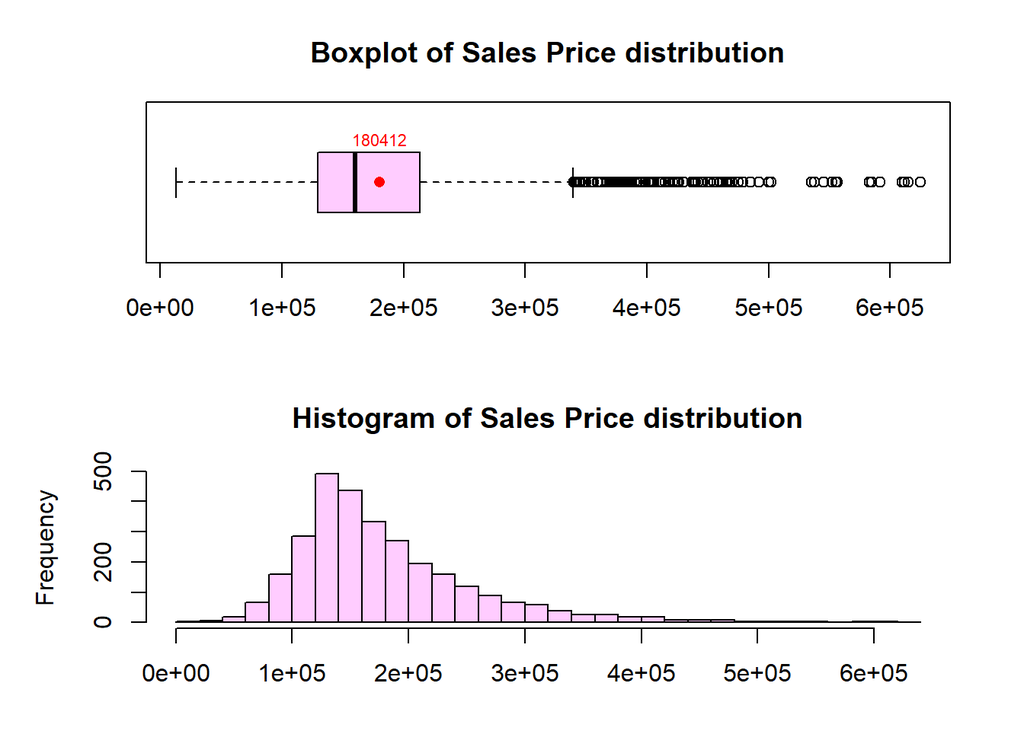

```r
# Distribution of independent variable SalePrice
par(mai=c(0.7,1,0.7,0.5),mfrow=c(2,1))
boxplot(df_main$SalePrice,horizontal=T,main="Boxplot of Sales Price distribution",col="#FFCCFF")

points(mean(df_main$SalePrice),y=1,col="red",pch=16)
text(mean(df_main$SalePrice),y=1.15,round(mean(df_main$SalePrice)),pos=3,cex=0.7,col="red")

hist(df_main$SalePrice,breaks=30,main="Histogram of Sales Price distribution",ylab="Frequency",xlab="",col="#FFCCFF")
```

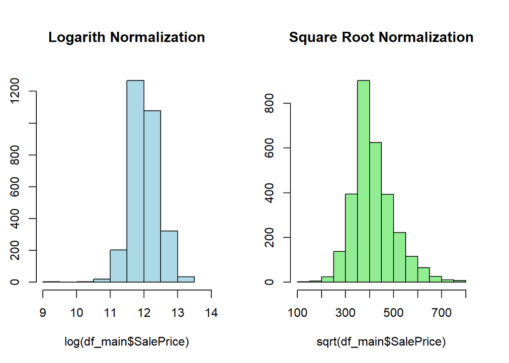

```r
# Normalize sales price
par(mai=c(1,0.5,1,0.5),mfrow=c(1,2))
hist(log(df_main$SalePrice),xlim=c(9,14),main="Logarith Normalization",col="lightblue")
hist(sqrt(df_main$SalePrice),main="Square Root Normalization",col="lightgreen")
```

P2 Observations:

- I was able to locate 5 irregular points when plotting the “SalePrice” vs the “Gr Liv Area” (highlighted red in the scatter plot). I decided to remove these 5 points by removing rows with “Gr Liv Area” that are larger than 4000 to form a new data set
- From the new data set, there are 43 categorical variables and 39 numerical variables
- Descriptive statistics of numerical variables show the count, mean, median, standard deviation, minimum and maximum values for each column. Descriptive statistics of categorical variables show the number of unique values and the count (excluding NAs) for each column. Both shows that there are some missing values in the data set
- The distribution of the independent variable SalePrice seems to be right-skewed (median < mean), so we should normalize it before performing our regression analysis
- The square root normalization method seems to work better, so I will choose the square root of SalePrice as my final independent variable for this assignment

## P3. Replace missing values

```r
# Replace missing values with NA for categorical variables
# Replace missing values with the variable's mean for numerical variables

dummy1 <- matrix()
for (i in 1:length(df_main)) {
  dummy1 <- as.matrix(df_main[,i])
  if (is.character(dummy1)==T) {
    dummy1[is.na(dummy1)] <- NA
    df_main[,i] <- dummy1
  } else {
    dummy1[is.na(dummy1)] <- round(mean(dummy1, na.rm=T))
    df_main[,i] <- dummy1
  }
}

# Updated data set
df_char <- select_if(df_main,is.character)
df_num <- select_if(df_main,is.numeric)
```

P3 Observations:

## P4. Produce correlation matrix

```r
cors <- cor(df_num, use="pairwise")
```

## P5. Produce a plot of the correlation matrix

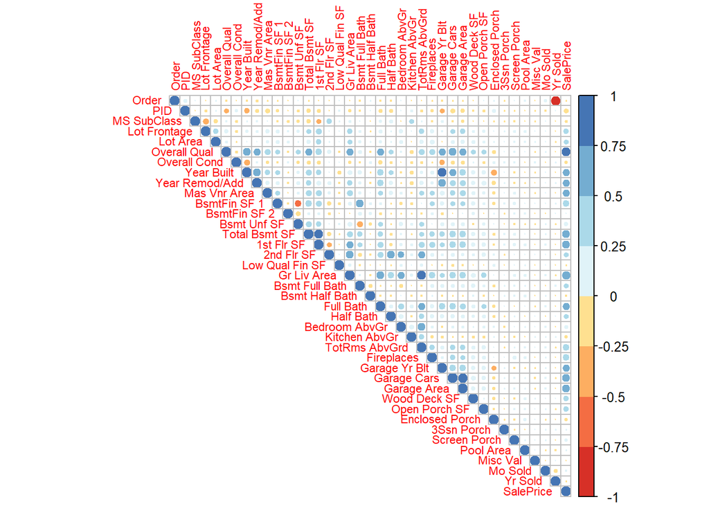

```r
corrplot(cors,type="upper",tl.cex=0.7,number.cex=0.7,col=brewer.pal(8,"RdYlBu"))
```

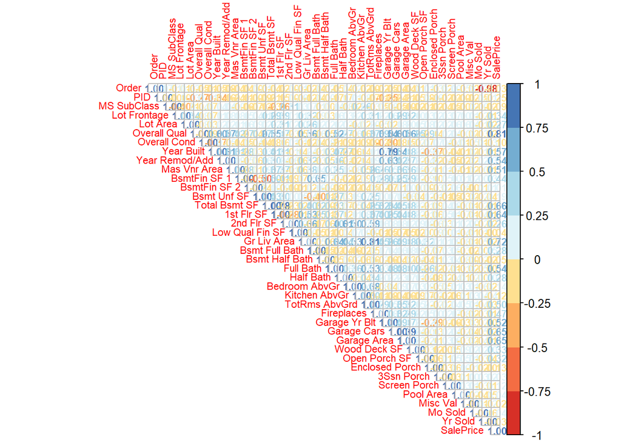

```r
corrplot(cors,method="number",type="upper",tl.cex=0.7,number.cex=0.7,col=brewer.pal(8,"RdYlBu"))
```

P5 Observations:

- Looking at the “SalePrice” column (last column in the matrix), we can observe which variables have high/low correlations with the sales price based on the circle colors
- We should exclude the “Order” and “PID” variables since the identification numbers don’t provide much values here
- For instance, it seems that “SalesPrice” is positively correlated with “Overall Qual” the most. It is negatively correlated with “Enclosed Porch” and “Kitchen AbvGr” the most. Finally, “SalePrice” is moderately correlated with “Mas Vnr Area”, where the correlation coefficient is close to 0.5.

## P6. Scatter plots with SalePrice

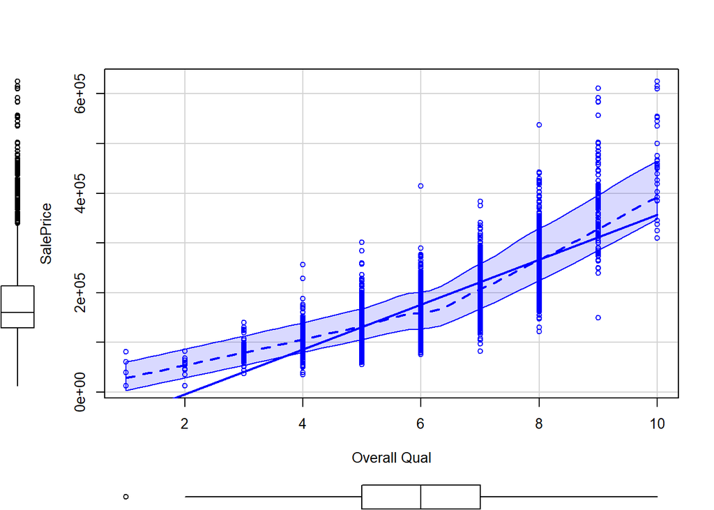

```r
# Scatter plot between SalePrice and highest correlated variable (closest to 1)
scatterplot(SalePrice ~ `Overall Qual`, data=df_main)
```

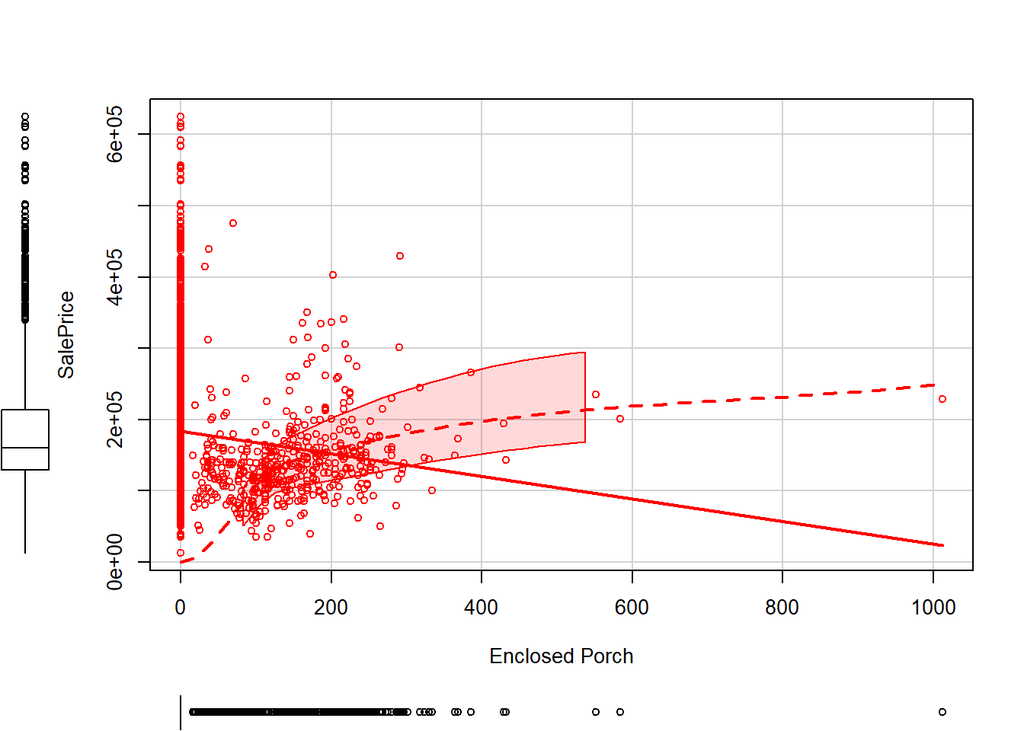

```r
# Scatter plot between SalePrice and lowest correlated variable (closest to -1)
scatterplot(SalePrice ~ `Enclosed Porch`, data=df_main,col="red")
```

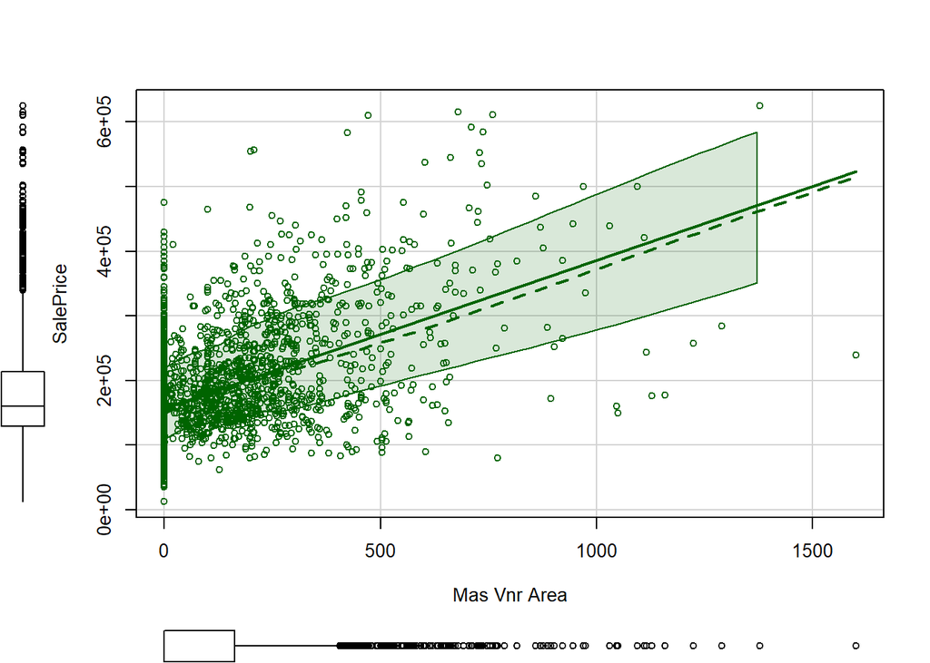

```r
# Scatter plot between SalePrice and moderately high correlated variable (closest to 0.5)
scatterplot(SalePrice ~ `Mas Vnr Area`, data=df_main,col="darkgreen")
```

## P7. Fit a regression model

```r
# Fit a regression model
fit_1 <- lm(SalePrice~ `Overall Qual`+ `Lot Area` + as.factor(Utilities) + `Enclosed Porch`, data=df_main)
summary(fit_1)
```

```
##
## Call:
## lm(formula = SalePrice ~ `Overall Qual` + `Lot Area` + as.factor(Utilities) +
##     `Enclosed Porch`, data = df_main)
##
## Residuals:
##     Min      1Q  Median      3Q     Max
## -273014  -26599   -2185   20023  296802
##
## Coefficients:
##                              Estimate Std. Error t value Pr(>|t|)
## (Intercept)                -1.072e+05  3.759e+03 -28.513   <2e-16 ***
## `Overall Qual`              4.391e+04  5.847e+02  75.087   <2e-16 ***
## `Lot Area`                  2.081e+00  1.045e-01  19.909   <2e-16 ***
## as.factor(Utilities)NoSeWa -4.866e+04  4.373e+04  -1.113   0.2659
## as.factor(Utilities)NoSewr -3.509e+04  3.100e+04  -1.132   0.2579
## `Enclosed Porch`           -3.027e+01  1.273e+01  -2.377   0.0175 *
## ---
## Signif. codes:  0 '***' 0.001 '**' 0.01 '*' 0.05 '.' 0.1 ' ' 1
##
## Residual standard error: 43720 on 2919 degrees of freedom
## Multiple R-squared:  0.6908, Adjusted R-squared:  0.6902
## F-statistic:  1304 on 5 and 2919 DF,  p-value: < 2.2e-16
```

## P8. Analyze the regression model

P8 Observations:

- The equation form of the model is [SalePrice] = -1.072e+05 + 4.39e+04∗[Overall Qual] + 2.08e+00∗[Lot Area] -4.87e+04∗[Utilities == “NoSeWa”] -3.51e+04∗[Utilities == “NoSeWr”] - 3.03e+01∗[Enclosed Porch]
- Based on this equation, we can assume that that Overal Quality and the Lot Area of the house help increase the sale price, while the number of enclosed porch decreases the sale price. We can also see that as opposed to having all public ultilities, having less utilities also decrease the sale price of the house.
- Among the 4 chosen variables, “Utilities” is considered statistically insignificant since its p-value is greater than 0.05, while all other variables are significant
- The R-squared and adjusted R-squared of the model, which describe how well the model fits into the given data set, are roughly 0.69. Therefore, we can state that this model can explain up to 69% of the variability in SalePrice around its mean. This shows that our current model has quite high accuracy

## P9. Plot your regression model

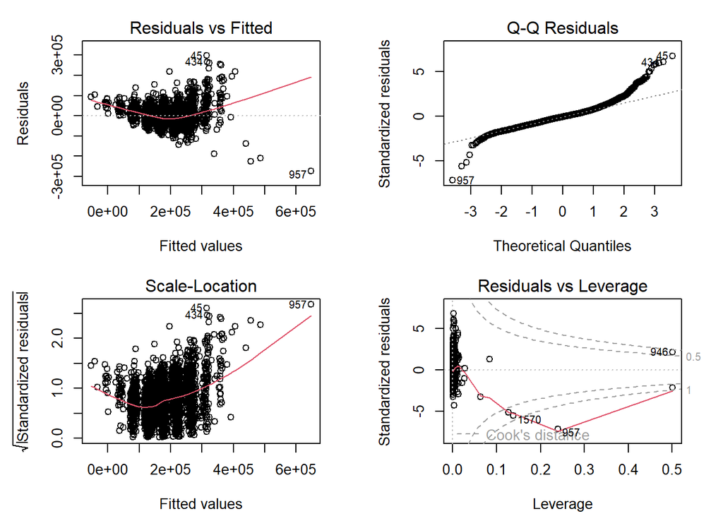

```r
# Plot regression model
par(mai=c(0.7,0.8,0.4,0.4),mfrow = c(2,2))
plot(fit_1)
```

## P10. Check for multicollinearity

```r
# Check for multicollinearity
# omcdiag(fit_1)
# imcdiag(fit_1)
vif(fit_1)
```

```
##                          GVIF Df GVIF^(1/(2*Df))
## `Overall Qual`       1.029523  1        1.014654
## `Lot Area`           1.011841  1        1.005903
## as.factor(Utilities) 1.005292  2        1.001320
## `Enclosed Porch`     1.021427  1        1.010657
```

P10 Observations:

I want to test whether there are multicollinearity occurrences within this model by looking at the Variation Inflation Factor (VIF) for each of the independent variable in the model using function vif(). The VIF shows what percentage the variance is inflated by for each coefficient if there was no correlation with other predictors. As a rule of thumb, the VIF values are interpreted as (Glen, 2015):

- 1 = not correlated
- Between 1 and 5 = moderately correlated
- Greater than 5 = highly correlated

We should consider removing variables with VIF value greater than 5 to avoid multicollinearity. We can observe from question 10 results that all of the VIF values (GVIF column) are close to 1. Therefore, our current model seems to have no problem with multicollinearity and we don’t need to remove any predictors.

## P11. Check for outliers

This was done previously in P2, where I removed 5 outliers with general living area greater than 4000 square feet.

## P12. Improve the exisiting model

```r
# Improve the regression model
fit_2 <- lm(sqrt(SalePrice)~ `Overall Qual`+ `Lot Area` + as.factor(Utilities) + `Enclosed Porch` + `Gr Liv Area` + `Mas Vnr Area`, data=df_main)
summary(fit_2)
```

```
##
## Call:
## lm(formula = sqrt(SalePrice) ~ `Overall Qual` + `Lot Area` +
##     as.factor(Utilities) + `Enclosed Porch` + `Gr Liv Area` +
##     `Mas Vnr Area`, data = df_main)
##
## Residuals:
##     Min      1Q  Median      3Q     Max
## -283.59  -21.73    0.91   22.93  174.03
##
## Coefficients:
##                              Estimate Std. Error t value Pr(>|t|)
## (Intercept)                 9.448e+01  3.405e+00  27.748  < 2e-16 ***
## `Overall Qual`              3.575e+01  6.316e-01  56.613  < 2e-16 ***
## `Lot Area`                  1.396e-03  9.282e-05  15.045  < 2e-16 ***
## as.factor(Utilities)NoSeWa -6.235e+01  3.759e+01  -1.659   0.0973 .
## as.factor(Utilities)NoSewr -4.603e+01  2.661e+01  -1.730   0.0838 .
## `Enclosed Porch`           -6.868e-02  1.102e-02  -6.234 5.21e-10 ***
## `Gr Liv Area`               5.784e-02  1.830e-03  31.600  < 2e-16 ***
## `Mas Vnr Area`              4.869e-02  4.464e-03  10.908  < 2e-16 ***
## ---
## Signif. codes:  0 '***' 0.001 '**' 0.01 '*' 0.05 '.' 0.1 ' ' 1
##
## Residual standard error: 37.52 on 2917 degrees of freedom
## Multiple R-squared:  0.8101, Adjusted R-squared:  0.8097
## F-statistic:  1778 on 7 and 2917 DF,  p-value: < 2.2e-16
```

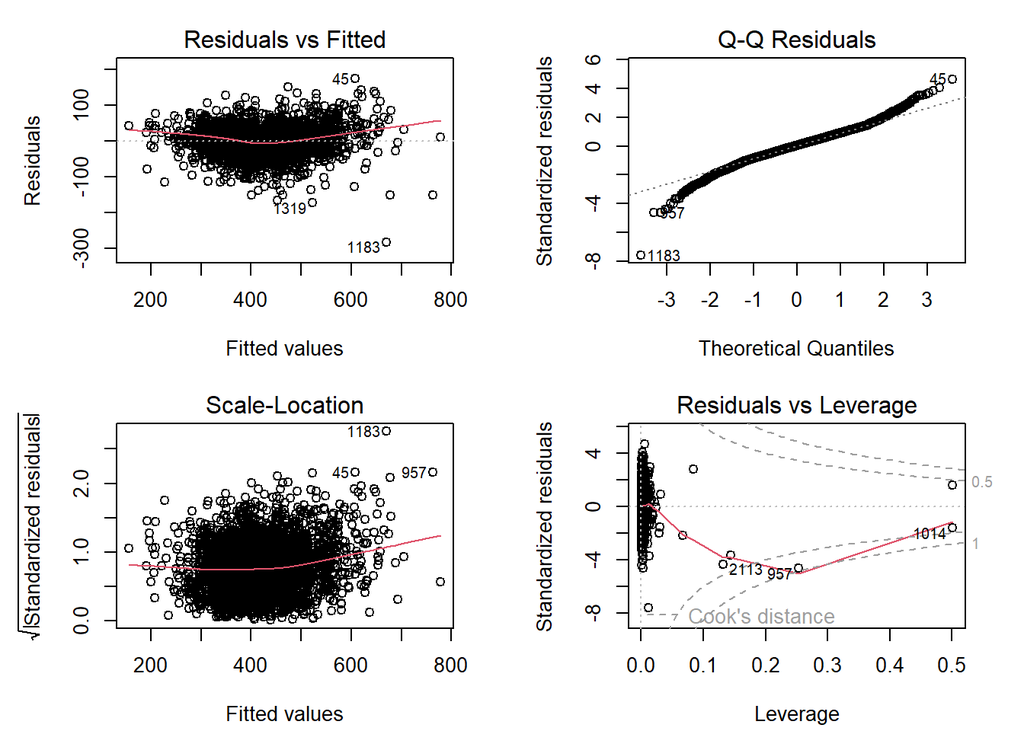

```r
# Check for normality, variance, and extreme cases
par(mai=c(0.7,0.8,0.4,0.4),mfrow = c(2,2))
plot(fit_2)
```

P12 Observations:

- In my attempt to improve my model, I decided to use square root of SalePrice as my independent variable and add “Gr Liv Area” and “Mas Vnr Area” as new predictors to my model
- The R-squared in this new model increases to roughly 0.81 from 0.69, which means there are some improvements made in terms of accuracy compared to the previous model
- Looking at the regression plots, there are definitely improvements as observed in the Residuals vs Fitted plot as well as the Scale-Location plot, where the non-linear patterns seem to have been removed and the predictors have roughly equal variances.

## P13. Use subsets regression method to determine the “best” model

```r
# Determine the 4 best predictors
leaps <- regsubsets(sqrt(SalePrice)~ `Overall Qual`+ `Lot Area` + as.factor(Utilities) + `Enclosed Porch` + `Gr Liv Area` + `Mas Vnr Area`, data=df_main, nvmax = 4)
summary(leaps)
```

```
## Subset selection object
## Call: regsubsets.formula(sqrt(SalePrice) ~ `Overall Qual` + `Lot Area` +
##     as.factor(Utilities) + `Enclosed Porch` + `Gr Liv Area` +
##     `Mas Vnr Area`, data = df_main, nvmax = 4)
## 7 Variables  (and intercept)
##                            Forced in Forced out
## `Overall Qual`                 FALSE      FALSE
## `Lot Area`                     FALSE      FALSE
## as.factor(Utilities)NoSeWa     FALSE      FALSE
## as.factor(Utilities)NoSewr     FALSE      FALSE
## `Enclosed Porch`               FALSE      FALSE
## `Gr Liv Area`                  FALSE      FALSE
## `Mas Vnr Area`                 FALSE      FALSE
## 1 subsets of each size up to 4
## Selection Algorithm: exhaustive
##          `Overall Qual` `Lot Area` as.factor(Utilities)NoSeWa
## 1  ( 1 ) "*"            " "        " "
## 2  ( 1 ) "*"            " "        " "
## 3  ( 1 ) "*"            "*"        " "
## 4  ( 1 ) "*"            "*"        " "
##          as.factor(Utilities)NoSewr `Enclosed Porch` `Gr Liv Area`
## 1  ( 1 ) " "                        " "              " "
## 2  ( 1 ) " "                        " "              "*"
## 3  ( 1 ) " "                        " "              "*"
## 4  ( 1 ) " "                        " "              "*"
##          `Mas Vnr Area`
## 1  ( 1 ) " "
## 2  ( 1 ) " "
## 3  ( 1 ) " "
## 4  ( 1 ) "*"
```

```r
# Regression results
fit_3 <- lm(sqrt(SalePrice)~ `Overall Qual`+ `Lot Area` + `Gr Liv Area` + `Mas Vnr Area`, data=df_main)
summary(fit_3)
```

```
##
## Call:
## lm(formula = sqrt(SalePrice) ~ `Overall Qual` + `Lot Area` +
##     `Gr Liv Area` + `Mas Vnr Area`, data = df_main)
##
## Residuals:
##      Min       1Q   Median       3Q      Max
## -284.599  -21.689    1.231   23.339  173.752
##
## Coefficients:
##                 Estimate Std. Error t value Pr(>|t|)
## (Intercept)    9.086e+01  3.385e+00   26.84   <2e-16 ***
## `Overall Qual` 3.638e+01  6.289e-01   57.84   <2e-16 ***
## `Lot Area`     1.378e-03  9.330e-05   14.78   <2e-16 ***
## `Gr Liv Area`  5.664e-02  1.831e-03   30.93   <2e-16 ***
## `Mas Vnr Area` 5.052e-02  4.475e-03   11.29   <2e-16 ***
## ---
## Signif. codes:  0 '***' 0.001 '**' 0.01 '*' 0.05 '.' 0.1 ' ' 1
##
## Residual standard error: 37.79 on 2920 degrees of freedom
## Multiple R-squared:  0.8072, Adjusted R-squared:  0.807
## F-statistic:  3057 on 4 and 2920 DF,  p-value: < 2.2e-16
```

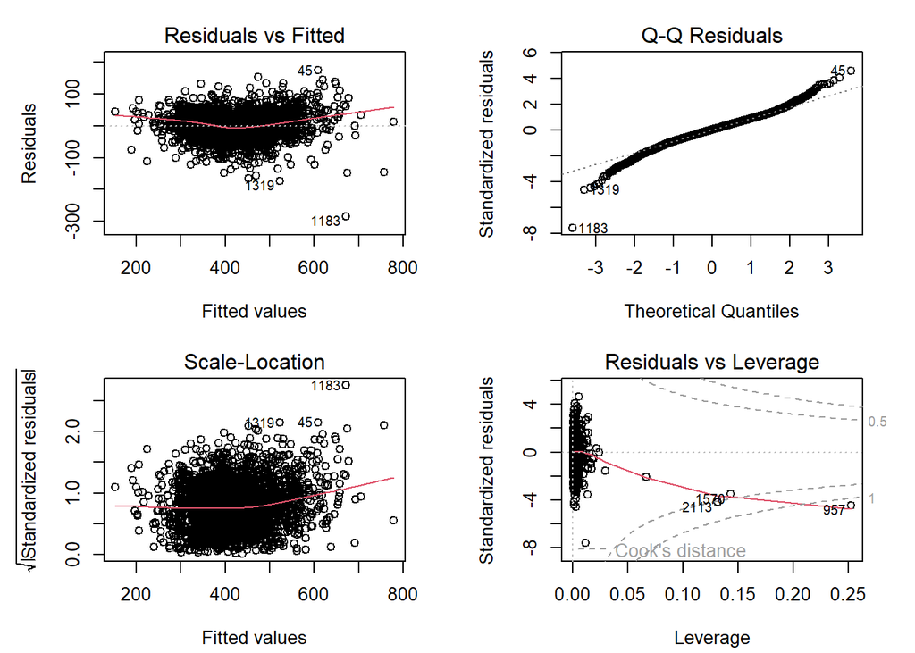

```r
# Check for normality, variance, and extreme cases
par(mai=c(0.7,0.8,0.4,0.4),mfrow = c(2,2))
plot(fit_3)
```

```r
# Check for multicollinearity
vif(fit_3)
```

```
## `Overall Qual`     `Lot Area`  `Gr Liv Area` `Mas Vnr Area`
##       1.593825       1.079296       1.623242       1.260309
```

## P14. How do the models differ? Which one do you prefer and why?

# III. CONCLUSION SECTION

In conclusion, by incorporating more predictor variables, new regression models with higher accuracy could be generated to closely predict the housing sale price. Following similar steps, I can conduct a stepwise selection method on all of the available dependent variables in the data set to pick out the most influential ones. From that, we can continue to refine our models by looking at the Variance Inflation Factor to help avoid multicollinearity. However, it’s important to note that there are no single correct answer when choosing between these models since different contexts will require different models. When looking to achieve the most accurate results for research purposes, one should look to include as much significant predictors as possible; but when looking for fast predictions with limited data input, one should use a less complicated model with only the most effective predictors to conduct their regression analysis.

# IV. REFERENCES

Kim, B. (2015, September 21). Understanding Diagnostic Plots for Linear Regression Analysis. Research Data Services + Sciences. Retrieved January 17, 2022, from https://data.library.virginia.edu/diagnostic-plots/

Glen, S. (2015, September 21). Variance inflation factor. Statistics How To. Retrieved January 16, 2022, from https://www.statisticshowto.com/variance-inflation-factor/